# Getting Started with genpca

## Fit a weighted analysis

`genpca()` takes a numeric matrix with **observations in rows and variables in columns**. A row metric `M` weights observations; a column metric `A` weights variables. With identity metrics and the same preprocessing, it recovers ordinary PCA.

Start with the three crime variables in `USArrests`: 50 states by 3 variables. Their spreads differ substantially. Set `A` to inverse column variances so that Assault does not dominate simply because of its numerical scale. This is equivalent to PCA on standardized columns.

```r
data("USArrests")
X <- as.matrix(USArrests[, c("Murder", "Assault", "Rape")])
col_sd <- apply(X, 2, sd)
A <- Diagonal(x = 1 / col_sd^2)
fit <- genpca(X, A = A, ncomp = 2,
              preproc = multivarious::center())

S <- multivarious::scores(fit)       # 50 states x 2 components
V <- multivarious::components(fit)   # 3 variables x 2 projection weights
round(cor(X, S), 2)
```

```
#>           PC1   PC2
#> Murder  -0.89 -0.36
#> Assault -0.93 -0.14
#> Rape    -0.83  0.55
```

The variable-score correlations give the axes an interpretation. PC1 moves with all three crime variables; PC2 contrasts Murder with Rape more strongly than it contrasts Assault with Rape. Component signs are arbitrary: reversing an axis leaves the analysis unchanged.

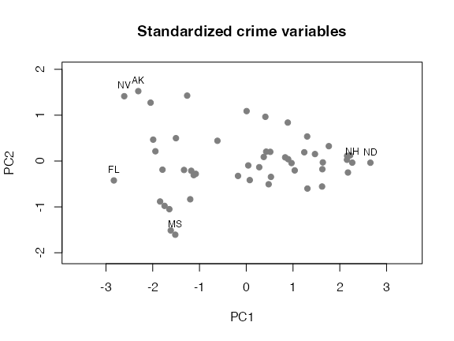

States in the two-component space after inverse-variance weighting of the crime variables. Six states with extreme scores are labelled.

To see the effect of scaling, compare each variable’s correlation with PC1 under the two fits. Absolute correlations remove the arbitrary axis sign.

```r
fit_raw <- genpca(X, ncomp = 2, preproc = multivarious::center())
round(cbind(
  unscaled = abs(cor(X, multivarious::scores(fit_raw)[, 1])),
  scaled   = abs(cor(X, S[, 1]))
), 2)
```

```
#>         [,1] [,2]
#> Murder  0.80 0.89
#> Assault 1.00 0.93
#> Rape    0.67 0.83
```

### Use the fitted object

The result is a `bi_projector`. Use its public accessors to inspect the fit, reconstruct the input, or project new rows with the training preprocessing.

```r
Xhat <- multivarious::reconstruct(fit)   # 50 x 3, back in original units
scores_again <- multivarious::project(fit, X)
max(abs(S - scores_again))              # numerical zero on training rows
```

```
#> [1] 8.881784e-16
```

| Operation | Output |
| --- | --- |
| `multivarious::scores(fit)` | `n x k` training coordinates |
| `multivarious::components(fit)` | `p x k` projection weights |
| `multivarious::project(fit, X_new)` | `n_new x k` coordinates, with training centering applied |
| `multivarious::reconstruct(fit, comp = 1:k)` | `n x p` reconstruction, with centering reversed |

New data must have the same variables in the same order. Centering is fitted on the training data; do not center a new batch separately before `project()`.

## Add observation weights

A diagonal `M` changes how much each row contributes to the objective. As an illustration, give greater weight to states with a higher urban population percentage. This is an analytical choice, not a claim that those states are more reliable or a weighting by total population.

```r
urban_wt <- USArrests$UrbanPop / mean(USArrests$UrbanPop)
M <- Diagonal(x = urban_wt)
fit_row <- genpca(X, M = M, A = A, ncomp = 2,
                  preproc = multivarious::center())
round(cor(X, multivarious::scores(fit_row)), 2)
```

```
#>          PC1   PC2
#> Murder  0.89  0.42
#> Assault 0.93  0.22
#> Rape    0.84 -0.49
```

The weights change the fitted axes; they do not push a state toward a particular signed end of an axis. This fit retains ordinary column centering through `multivarious::center()`; setting `M` does not change that preprocessing into weighted centering.

## Choose the number of components

`fit$sdev` contains singular values of the metric-whitened data. With identity metrics and centering, these equal `prcomp(X)$sdev * sqrt(nrow(X) - 1)`. Fit the full available spectrum before using a scree plot to choose a rank:

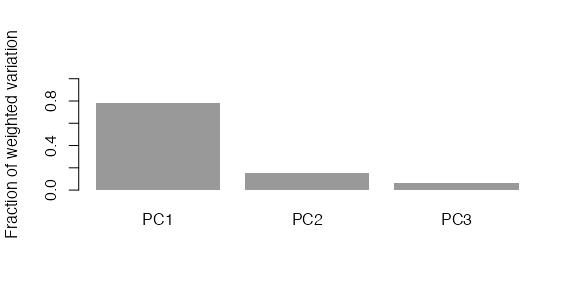

Fraction of total weighted variation for all three available components.

```r
fit_all <- genpca(X, A = A, ncomp = ncol(X),
                  preproc = multivarious::center())
share <- fit_all$sdev^2 / sum(fit_all$sdev^2)
barplot(share, names.arg = paste0("PC", seq_along(share)),
        ylim = c(0, 1), ylab = "Fraction of weighted variation",
        col = "grey60", border = NA)
```

The first two components account for 93.9% of the weighted variation in this example. A scree plot describes the training fit; it does not establish how well components will generalize. For prediction, compare held-out reconstruction error using preprocessing and data-derived metrics estimated on training rows only.

## Where next

- GPCA Metrics: construct row and column metrics and choose between smoothing and noise whitening.
- Modelling Structured Noise: explore those choices with known signal and noise in simulations.
- GPCA at Scale: choose a backend, budget memory, and project held-out observations.
- Sparse and Functional PCA: fit sparse, smooth factors.
- Generalized PLS-SVD: relate two data blocks, with an explicit whitening reference for contributors.

The remaining sections explain the mathematics and notation behind the fit.

## The decomposition

### Two metrics, one weighted objective

Let $X$ be the $n \times p$ data matrix. Generalized PCA asks you to supply two symmetric positive semi-definite matrices:

- $M$ ($n \times n$), the **row metric**, which puts a geometry on the space of observations;
- $A$ ($p \times p$), the **column metric**, which puts a geometry on the space of variables.

For positive definite metrics, they define an inner product on $n \times p$ matrices,

$$\langle Y, Z \rangle_{M,A} \;=\;
\operatorname{tr}\!\left(Y^{\top} M Z A\right),
\qquad
\|Y\|_{M,A}^{2} \;=\; \operatorname{tr}\!\left(Y^{\top} M Y
A\right).$$

When $M = I_n$ and $A = I_p$ this is the ordinary Frobenius inner product, and the decomposition reduces to the familiar SVD and PCA. Singular PSD metrics instead define a seminorm: directions in their null spaces have zero weight. Here $X$ denotes the preprocessed data, after centering if requested.

### The problem it solves

The **generalized least-squares matrix decomposition** (GMD) of Allen, Grosenick & Taylor (2014) is the best rank-$K$ approximation of $X$ *in that norm*:

$$\min_{U, D, V} \;\bigl\|X - U D
V^{\top}\bigr\|_{M,A}^{2}
\qquad \text{subject to} \qquad
U^{\top} M U = I_K, \quad V^{\top} A V = I_K,$$

with $D = \operatorname{diag}(d_1 \ge d_2 \ge \cdots \ge d_K \ge 0)$.

Only two things changed relative to the SVD, and they are the same change twice: the discrepancy is measured in the $(M,A)$ norm rather than the Frobenius norm, and the factors are orthonormal *in the metrics* rather than Euclidean-orthonormal.

### The solution: whiten, decompose, unwhiten

The problem has a closed form. Take symmetric square roots $M = M^{1/2}M^{1/2}$ and $A = A^{1/2}A^{1/2}$, whiten the data,

$$\widetilde{X} \;=\; M^{1/2} X
A^{1/2},$$

and compute its *ordinary* SVD, $\widetilde{X} = \widetilde{U} D \widetilde{V}^{\top}$. Then

$$U = M^{-1/2}\widetilde{U}, \qquad V =
A^{-1/2}\widetilde{V}, \qquad D \text{ unchanged}$$

solves the problem above (with pseudo-inverses when a metric is singular). GMD is therefore an SVD in the coordinates selected by the metrics.

For positive definite metrics, eliminating the whitening gives the eigenproblem

$$X^{\top} M X A \, v_k \;=\; d_k^{2}\,
v_k, \qquad v_k^{\top} A v_k = 1,$$

and the $k$-th generalized principal component (the score vector) is

$$z_k \;=\; X A v_k \;=\; d_k\, u_k
.$$

For singular metrics, the pseudo-inverse factors solve the problem on the metrics’ supported subspaces; the identities above need the corresponding projections when interpreted outside those subspaces.

In the package these are `components(fit)` $= A\,$`ov` for the loadings and `scores(fit)` $=$ `ou %*% diag(sdev)` for the scores, with `ou` and `ov` holding the metric-orthonormal factors $U$ and $V$.

### What the metrics mean

There are two readings of $M$ and $A$, and both are worth carrying.

**As geometry.** The metrics define what “distance” means, and they act crosswise. Observations are rows of $X$, living in $\mathbb{R}^p$, so the *column* metric sets the distance between two observations, $\|x_i - x_j\|_A^2 = (x_i - x_j)^{\top} A\,(x_i - x_j)$. Variables are columns, living in $\mathbb{R}^n$, so the *row* metric sets the distance between two variables — and, when $M$ is diagonal, simply weights the observations. Choose $A$ to say which variables should be treated as similar; choose $M$ to say which observations count more.

**As statistics.** Suppose the noise is separable, meaning the errors follow a matrix-normal law $E \sim \mathcal{MN}(0, \Sigma_{\text{row}}, \Sigma_{\text{col}})$, equivalently $\operatorname{vec}(E)$ has covariance $\Sigma_{\text{col}} \otimes \Sigma_{\text{row}}$. Then the log-likelihood of a rank-$K$ mean is, up to constants, exactly $-\tfrac12\|X - UDV^{\top}\|^2_{M,A}$ with

$$M = \Sigma_{\text{row}}^{-1}, \qquad A =
\Sigma_{\text{col}}^{-1}.$$

So the metrics are not an arbitrary regularizer: setting them to the inverse noise covariances makes GMD the maximum-likelihood low-rank fit. This is why the package ships `gpca_mle()`, which learns $(M, A)$ by penalized maximum likelihood, and `mnpca_mrl()`, which does the same with sparse precision matrices.

## Choosing structured metrics

Use GPCA Metrics: Building M and A for runnable recipes. The direction of the weighting matters:

- To favour smooth column loadings, start with a PSD kernel or a smoother such as $A = (I + \alpha L)^{-1}$, where $L$ is a graph Laplacian. A raw adjacency or distance matrix need not be PSD and cannot be used without a valid metric construction.
- To account for correlated noise, use its **inverse covariance**. For a time-by-voxel table with separable Gaussian noise, choose $M = \Sigma_{\mathrm{time}}^{-1}$ and $A = \Sigma_{\mathrm{space}}^{-1}$. The row metric acts on time and the column metric on space. A covariance model for related samples likewise enters through its inverse when the goal is noise whitening.
- `sfpca()` encourages smooth, sparse factors through a different constraint. Its spatial penalty is built from `spat_cds`; increasing `alpha_v` strengthens that penalty. See Sparse and Functional PCA before transferring tuning choices between the two interfaces.

A Laplacian as `A` emphasizes contrasts across graph edges; its inverse (with a ridge to make it invertible) emphasizes smooth directions. Select between these according to whether smooth variation is signal or nuisance.

## Choosing a backend

The default `method = "eigen"` uses a Gram eigenproblem on the smaller side of the data. `"spectra"` usually applies eigencore’s partial SVD to a whitened operator, with a dense fallback and a small-side Gram route for a singular large-side metric. `"randomized"` approximates a leading subspace; `"deflation"` extracts components one at a time and can preserve sparse data.

Neither `"spectra"` nor `"randomized"` preserves sparse `X`: both make a dense data copy. Metric factorizations and fallback storage also matter. GPCA at Scale describes those costs, the `maxeig` guard, and the covariance-only interface.

## What are `ou`, `ov`, `u`, and `v`?

Under the hood, `genpca()` stores the raw factors of the decomposition alongside the verbs above. `ou` and `ov` are the metric-orthonormal factors of the paper (Allen, Grosenick & Taylor 2014): `ou` is orthonormal in the row metric (`t(ou) %*% M %*% ou` is the identity) and `ov` is orthonormal in the column metric (`t(ov) %*% A %*% ov` is the identity). `u` and `v` are the same factors after applying the metric (`u = M %*% ou`, `v = A %*% ov`), which is the form used for `components()`. The table below ties these to the verbs:

| Quantity | Definition | Relation to verbs |
| --- | --- | --- |
| `ou` | Row-metric-orthonormal left factor | `t(ou) %*% M %*% ou = I` |
| `ov` | Column-metric-orthonormal right factor | `t(ov) %*% A %*% ov = I` |
| `v` (`components(fit)`) | `A %*% ov` | Loadings in the original variable space |
| `s` (`scores(fit)`) | `ou %*% diag(sdev)` | Stored training scores |

Here the decomposition applies to the preprocessed matrix `Xp`, not raw `X`. For positive definite metrics, the score formula is `Xp %*% A %*% ov`. `project()` applies the stored preprocessing before multiplying by the projection weights. With singular metrics, null-space representatives can make projected coordinates differ from the stored factor scores outside the weighted subspace.

## Relation to the French school

Readers coming from *analyse des données* will recognize all of this. The French tradition — Benzécri’s correspondence analysis, formalized by Escoufier as the **duality diagram** — describes an analysis by a *triplet* $(X, Q, D)$: a data table, a metric on the variable space, and a set of row masses. The analysis is then the eigendecomposition of the operator $X^{\top} D X Q$. That is, term for term, the eigenproblem in The decomposition. Correspondence analysis, multiple correspondence analysis, principal coordinates, discriminant analysis, canonical correlation, and PLS are all recovered by choosing the triplet appropriately; the `ade4` package is built directly on this formalism, and Abdi’s papers on the generalized SVD — cited in this package’s `DESCRIPTION` — are the same construction in English.

Watch the notation: **$Q$ means opposite things in the two literatures.**

| Role | `genpca` | Allen et al. (2014) | Duality diagram |
| --- | --- | --- | --- |
| Row metric / observation weights | `M` | $Q$ | $D$ |
| Column metric / variable geometry | `A` | $R$ | $Q$ |

What Allen, Grosenick & Taylor contribute on top of the classical theory is less the geometry than the framing and the machinery: the decomposition is posed as a *best rank-$K$ approximation* with an optimality theorem rather than only an eigenanalysis; the metrics are allowed to be large, dense, and structured (spatial kernels, temporal covariances) instead of the diagonal weights typical of the classical treatments; and the formulation extends cleanly to regularized and sparse variants, which is what `sfpca()` implements.

## References

Allen, G. I., Grosenick, L., & Taylor, J. (2014). A generalized least-square matrix decomposition. *Journal of the American Statistical Association*, 109(505), 145–159.

Escoufier, Y. (1987). The duality diagram: a means for better practical applications. In *Development in Numerical Ecology*. Springer.

Holmes, S. (2008). Multivariate data analysis: the French way. In *Probability and Statistics: Essays in Honor of David A. Freedman*. IMS.

Dray, S., & Dufour, A.-B. (2007). The ade4 package: implementing the duality diagram for ecologists. *Journal of Statistical Software*, 22(4).

Silverman, B. W. (1996). Smoothed functional principal components analysis by choice of norm. *The Annals of Statistics*, 24(1), 1–24.